# EDA

**Autor:** AGUSTÍN SILVIO ANDRÉS ROJAS

**Fecha:** 3/9/2025

# Index

1. Packages
2. Data exploration
3. Plots

   3.1. Correlation matrix

   3.2. TOP CORRELATIONS BAR CHART

   3.3. FRAUD DISTRIBUTION

   3.3.0. BOXPLOTS BY FRAUD STATUS

   3.3.1. FRAUD RATE BY CATEGORICAL VARIABLES

   3.3.2. FRAUD RATE BY BINARY VARIABLES

   3.3.3. TIME-BASED ANALYSIS

   3.3.4. DISTRIBUCIONES DE ALGUNAS VARIABLES NÚMERICAS
4. Outliers
5. Conclusiones

   5.1 Guardado de subconjuntos de datos y reporte

# Data exploration

|  | transaction_datetime | amount | user_age | user_income | device_type | os_type | browser | country | city_size | num_products | ... | transaction_month | is_night | is_weekend | amount_to_income_ratio | avg_product_price | high_value_transaction | new_customer | unusual_device_combo | is_fraud | user_id |
| --- | --- | --- | --- | --- | --- | --- | --- | --- | --- | --- | --- | --- | --- | --- | --- | --- | --- | --- | --- | --- | --- |
| 48372 | 2023-12-30 | 1084.95 | 62 | 114577 | tablet | iOS | Chrome | ARS | Suburban | 2 | ... | 12 | 1 | 1 | 0.113630 | 542.475000 | 1 | 0 | 0 | 0 | 48373 |
| 47241 | 2023-12-30 | 3144.30 | 42 | 91686 | mobile | Android | Firefox | BR | Metro | 1 | ... | 12 | 1 | 1 | 0.411531 | 3144.300000 | 1 | 0 | 0 | 0 | 47242 |
| 8781 | 2023-12-30 | 939.75 | 59 | 90966 | mobile | iOS | Chrome | US | Metro | 3 | ... | 12 | 1 | 1 | 0.123969 | 313.250000 | 0 | 0 | 0 | 0 | 8782 |
| 37436 | 2023-12-30 | 714.03 | 18 | 104386 | desktop | Android | Chrome | BR | Metro | 2 | ... | 12 | 1 | 1 | 0.082083 | 357.015000 | 0 | 0 | 0 | 0 | 37437 |
| 5880 | 2023-12-30 | 620.41 | 74 | 103092 | desktop | Windows | Safari | UK | Metro | 3 | ... | 12 | 1 | 1 | 0.072216 | 206.803333 | 0 | 0 | 0 | 0 | 5881 |
| ... | ... | ... | ... | ... | ... | ... | ... | ... | ... | ... | ... | ... | ... | ... | ... | ... | ... | ... | ... | ... | ... |
| 44246 | 2023-01-01 | 5396.78 | 35 | 79723 | mobile | Windows | Edge | US | Suburban | 2 | ... | 1 | 1 | 1 | 0.812330 | 2698.390000 | 1 | 0 | 1 | 1 | 44247 |
| 23071 | 2023-01-01 | 721.59 | 51 | 66936 | mobile | Android | Firefox | MX | Metro | 4 | ... | 1 | 1 | 1 | 0.129364 | 180.397500 | 0 | 0 | 0 | 1 | 23072 |
| 37578 | 2023-01-01 | 95.95 | 18 | 94644 | mobile | Windows | Safari | UK | Urban | 2 | ... | 1 | 1 | 1 | 0.012166 | 47.975000 | 0 | 0 | 1 | 1 | 37579 |
| 8476 | 2023-01-01 | 934.81 | 31 | 82431 | mobile | MacOS | Firefox | UK | Urban | 2 | ... | 1 | 1 | 1 | 0.136086 | 467.405000 | 0 | 0 | 0 | 1 | 8477 |
| 30109 | 2023-01-01 | 201.03 | 53 | 88594 | mobile | Windows | Edge | ARS | Metro | 4 | ... | 1 | 1 | 1 | 0.027229 | 50.257500 | 0 | 0 | 1 | 1 | 30110 |

50000 rows × 26 columns

```
Información sobre el set de datos:  <class 'pandas.core.frame.DataFrame'>
Cantidad de Filas y columnas: (50000, 26)
Nombre columnas: Index(['transaction_datetime', 'amount', 'user_age', 'user_income',
       'device_type', 'os_type', 'browser', 'country', 'city_size',
       'num_products', 'repeat_customer', 'account_age_days',
       'previous_chargebacks', 'is_dead_user', 'transaction_hour',
       'transaction_day', 'transaction_month', 'is_night', 'is_weekend',
       'amount_to_income_ratio', 'avg_product_price', 'high_value_transaction',
       'new_customer', 'unusual_device_combo', 'is_fraud', 'user_id'],
      dtype='object')
```

```
transaction_datetime      datetime64[ns]
amount                           float64
user_age                           int32
user_income                        int64
device_type                       object
os_type                           object
browser                           object
country                           object
city_size                         object
num_products                       int32
repeat_customer                    int64
account_age_days                   int32
previous_chargebacks               int32
is_dead_user                       int64
transaction_hour                   int32
transaction_day                    int32
transaction_month                  int32
is_night                           int64
is_weekend                         int64
amount_to_income_ratio           float64
avg_product_price                float64
high_value_transaction             int64
new_customer                       int64
unusual_device_combo               int64
is_fraud                           int32
user_id                            int64
dtype: object
```

```
Cantidad de valores unicos por columna:
 is_night                      1
new_customer                  1
transaction_hour              1
high_value_transaction        2
unusual_device_combo          2
is_dead_user                  2
is_fraud                      2
repeat_customer               2
is_weekend                    2
device_type                   3
previous_chargebacks          4
browser                       4
os_type                       4
city_size                     4
country                       5
transaction_day               7
transaction_month            12
num_products                 12
user_age                     57
account_age_days            150
transaction_datetime        364
user_income               33038
amount                    42775
avg_product_price         46241
amount_to_income_ratio    50000
user_id                   50000
dtype: int64
```

```
No hay valores nulos en el DataFrame.
```

```
Numerical columns:
['amount', 'user_age', 'user_income', 'num_products', 'account_age_days', 'previous_chargebacks', 'transaction_day', 'transaction_month', 'amount_to_income_ratio', 'avg_product_price']
Categorical columns:
['device_type', 'os_type', 'browser', 'country', 'city_size']
Binary columns:
['repeat_customer', 'is_dead_user', 'transaction_hour', 'is_night', 'is_weekend', 'high_value_transaction', 'new_customer', 'unusual_device_combo']
```

```
Estadísticas básicas de la variables numéricas
                          count      mean       std       min       25%  \
amount                  50000.0   2013.58   4766.07      0.02    186.08
user_age                50000.0     45.82     16.45     18.00     32.00
user_income             50000.0  90038.16  14998.38  30010.00  79960.00
num_products            50000.0      3.00      1.41      1.00      2.00
account_age_days        50000.0    365.00     19.08    272.00    352.00
previous_chargebacks    50000.0      0.10      0.31      0.00      0.00
transaction_day         50000.0      3.01      2.00      0.00      1.00
transaction_month       50000.0      6.48      3.45      1.00      3.00
amount_to_income_ratio  50000.0      0.28      0.67      0.00      0.02
avg_product_price       50000.0    861.26   2362.71      0.00     63.95

                             50%        75%        max
amount                    473.05    1185.06   71345.37
user_age                   46.00      60.00      74.00
user_income             90021.50  100121.50  153030.00
num_products                3.00       4.00      12.00
account_age_days          365.00     378.00     445.00
previous_chargebacks        0.00       0.00       3.00
transaction_day             3.00       5.00       6.00
transaction_month           6.00       9.00      12.00
amount_to_income_ratio      0.06       0.16      16.86
avg_product_price         177.18     502.86   70589.75
```

```
Proporción de la variable 'repeat_customer': 70.16%
Proporción de la variable 'is_dead_user': 0.02%
Proporción de la variable 'transaction_hour': 0.00%
Proporción de la variable 'is_night': 100.00%
Proporción de la variable 'is_weekend': 28.88%
Proporción de la variable 'high_value_transaction': 28.72%
Proporción de la variable 'new_customer': 0.00%
Proporción de la variable 'unusual_device_combo': 15.05%
```

```
Monto total de transacciones: $100,678,883.85
Monto total perdido por fraudes: $41,796,570.12
Porcentaje perdido del total de transacciones: 41.51%
Que porcentaje representas el monto perdido por fraude respecto de al monto de transacciones legítimas: 70.98%
```

# Plots

## Correlation matrix

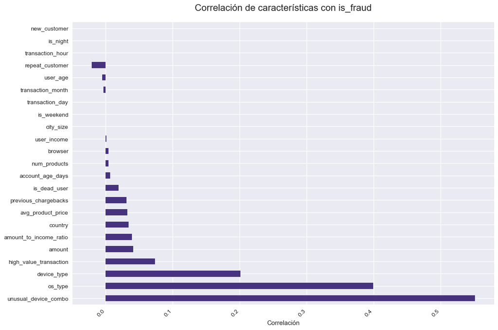

## TOP CORRELATIONS BAR CHART

```
unusual_device_combo      0.551695
os_type                   0.399268
device_type               0.201114
high_value_transaction    0.073685
amount                    0.041411
amount_to_income_ratio    0.039448
country                   0.034514
avg_product_price         0.032318
previous_chargebacks      0.031079
is_dead_user              0.019445
dtype: float64
```

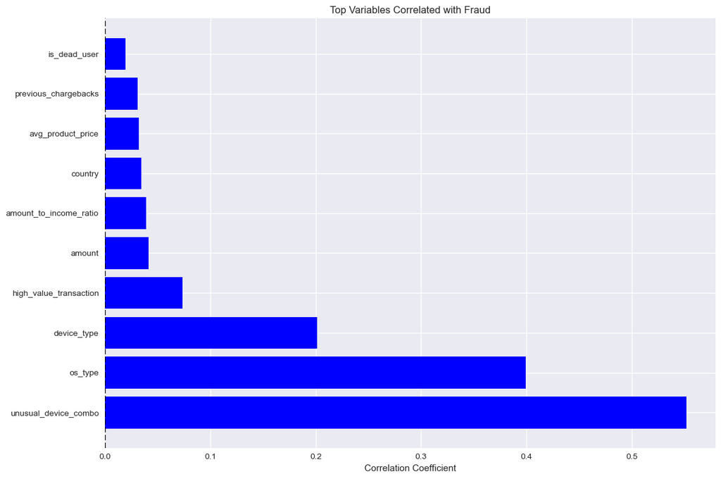

## FRAUD DISTRIBUTION

```
Distribución de fraudes:
is_fraud
0    31606
1    18394
Name: count, dtype: int64
Porcentaje de fraudes: 36.79%
```

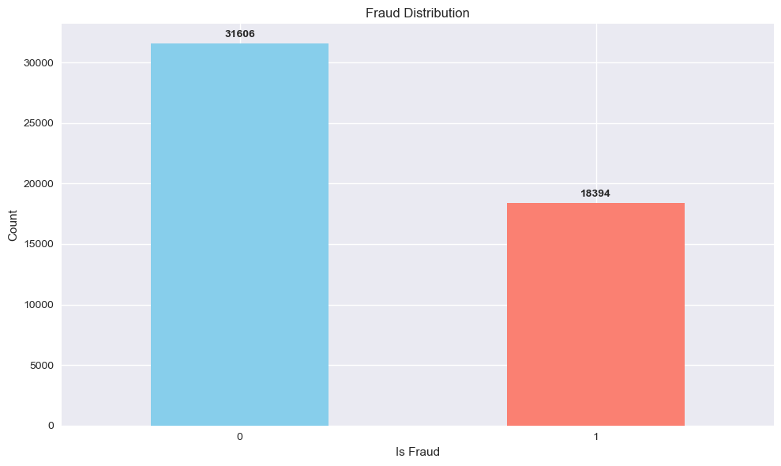

### BOXPLOTS BY FRAUD STATUS

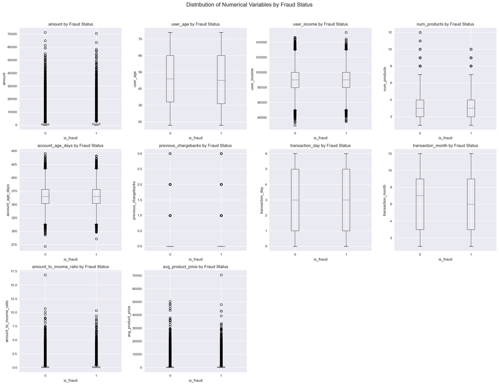

Los box plots entre si es fraude o no de las variables númericas no indican diferencias claras.

### FRAUD RATE BY CATEGORICAL VARIABLES

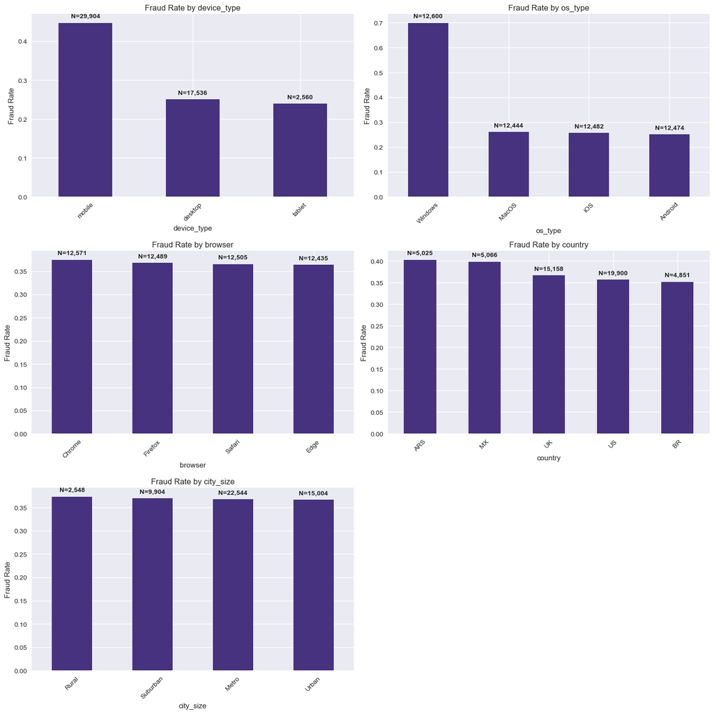

```
Analisis de fraude de os_type = Windows
Probabilidad de fraude por os_type = Windows: 0.6996031746031746
Dinero perdido por fraude por os_type = Windows $18,097,684.45
Porcentaje de perdida  por fraude por os_type = Windows respecto al total de transacciones: 17.98%
Porcentaje de perdida por fraude por os_type = Windows respecto al total de transacciones no fraudulentas: 30.74%
Porcentaje de perdida de los fraudes por os_type = Window del total de fraudes: 43.3%
Cantidad de fraudes por os_type = Windows: 8,815
--------------------
Analisis de fraude de device_type = mobile
Probabilidad de fraude por device_type = mobile: 0.4473983413590155
Dinero perdido por fraude por device_type = mobile $29,761,021.71
Porcentaje de perdida  por fraude por device_type = mobile respecto al total de transacciones: 29.56%
Porcentaje de perdida por fraude por device_type = mobile respecto al total de transacciones no fraudulentas: 50.54%
Porcentaje de perdida de los fraudes por device_type = mobile del total de fraudes: 71.2%
Cantidad de fraudes por device_type = mobile: 13,379
--------------------
Analisis de fraude de device_type = mobile y os_type = Windows
Probabilidad de fraude por device_type = mobile y os_type = Windows: 1.0
Dinero perdido por fraude por device_type = mobile y os_type = Windows $14,927,482.25
Porcentaje de perdida  por fraude por device_type = mobile y os_type = Windows respecto al total de transacciones: 14.83%
Porcentaje de perdida por fraude por device_type = mobile y os_type = Windows respecto al total de transacciones no fraudulentas: 25.35%
Porcentaje de perdida de los fraudes por device_type = mobile y os_type = Windows del total de fraudes: 35.71%
Cantidad de fraudes por device_type = mobile y os_type = Windows: 7,524
--------------------
```

```
Analisis de fraude de device_type = mobile y os_type != Windows
Probabilidad de fraude por device_type = mobile y os_type != Windows: 0.26161751563896335
Dinero perdido por fraude por device_type = mobile y os_type != Windows $14,833,539.46
Porcentaje de perdida  por fraude por device_type = mobile y os_type != Windows respecto al total de transacciones: 14.73%
Porcentaje de perdida por fraude por device_type = mobile y os_type != Windows respecto al total de transacciones no fraudulentas: 25.19%
Porcentaje de perdida de los fraudes por device_type = mobile y os_type != Windows del total de fraudes: 35.49%
Cantidad de fraudes por device_type = mobile y os_type != Windows: 5,855
--------------------
```

```
Analisis de fraude de device_type != mobile y os_type = Windows
Probabilidad de fraude por device_type != mobile y os_type = Windows: 0.25433412135539796
Dinero perdido por fraude por device_type != mobile y os_type = Windows $3,170,202.2
Porcentaje de perdida  por fraude por device_type != mobile y os_type = Windows respecto al total de transacciones: 3.15%
Porcentaje de perdida por fraude por device_type != mobile y os_type = Windows respecto al total de transacciones no fraudulentas: 5.38%
Porcentaje de perdida de los fraudes por device_type != mobile y os_type = Windows del total de fraudes: 7.58%
Cantidad de fraudes por device_type != mobile y os_type = Windows: 1,291
--------------------
```

### FRAUD RATE BY BINARY COLUMNS

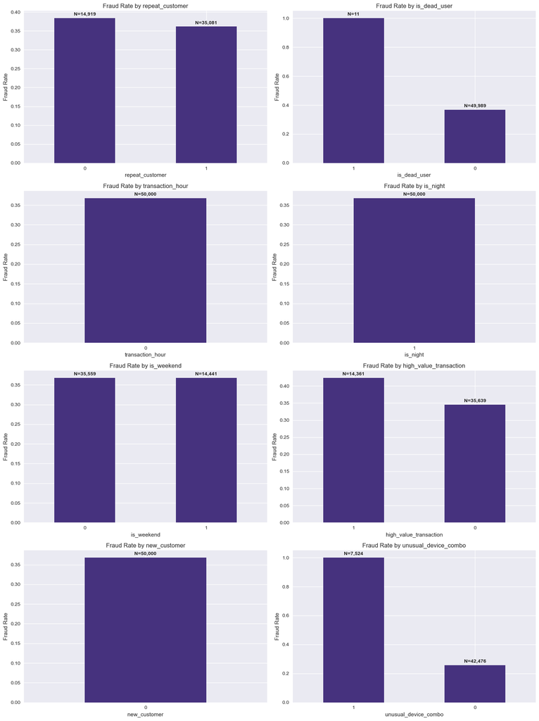

```
Analisis de fraude de is_dead_user
Probabilidad de fraude por is_dead_user: 1.0
Dinero perdido por fraude por usuarios 'muertos' $12,439.92
Porcentaje de perdida respecto al total de transacciones por fraude por usuarios 'muertos': 0.01%
Porcentaje de perdida respecto al total de transacciones no fraudulentas por fraude por usuarios 'muertos': 0.02%
Porcentaje que representan los fraudes por usuarios 'muertos' del total de fraudes: 0.03%
Analisis de fraude de unusual_device_combo
Probabilidad de fraude por unusual_device_combo: 1.0
Dinero perdido por fraude por unusual_device_combo $14,927,482.25
Porcentaje de perdida respecto al total de transacciones por fraude por unusual_device_combo: 14.83%
Porcentaje de perdida respecto al total de transacciones no fraudulentas por fraude por unusual_device_combo: 25.35%
Porcentaje que representan los fraudes por unusual_device_combo del total de fraudes: 35.71%
```

### TIME-BASED ANALYSIS

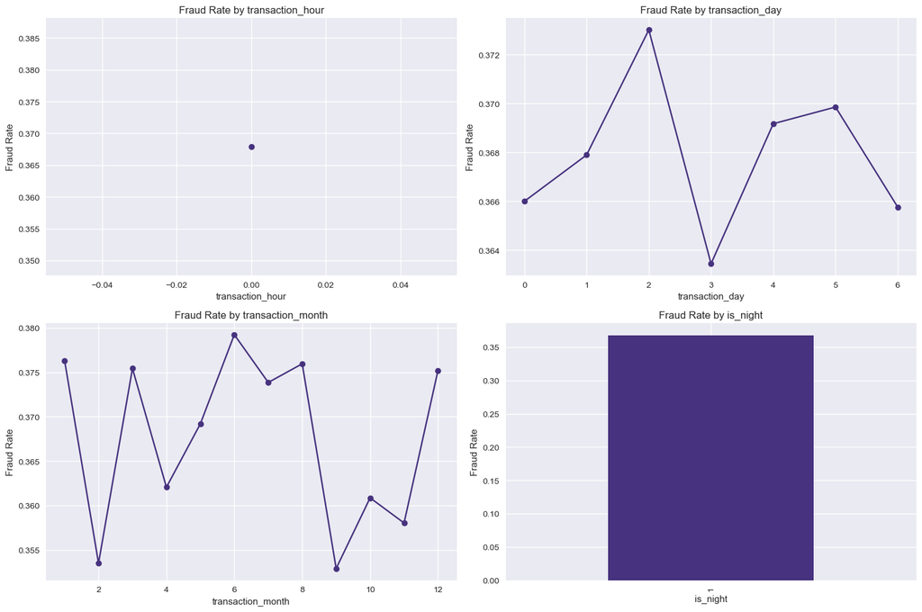

### DISTRIBUCIONES DE ALGUNAS VARIABLES NÚMERICAS

[figure not shown]

```
All plots saved to: c:\Users\agust\OneDrive\Documentos\VScode\Fraudes\mlparadetectarfraudes\notebooks\..\reports\figures
```

# Outliers

```
Outliers for amount saved to CSV.
Outliers for user_income saved to CSV.
Outliers for user_income saved to CSV.
Outliers for num_products saved to CSV.
Outliers for num_products saved to CSV.
Outliers for account_age_days saved to CSV.
Outliers for account_age_days saved to CSV.
Outliers for previous_chargebacks saved to CSV.
Outliers for is_dead_user saved to CSV.
Outliers for previous_chargebacks saved to CSV.
Outliers for is_dead_user saved to CSV.
Outliers for amount_to_income_ratio saved to CSV.
Outliers for amount_to_income_ratio saved to CSV.
Outliers for avg_product_price saved to CSV.
Outliers for avg_product_price saved to CSV.
Outliers for unusual_device_combo saved to CSV.
Outliers for unusual_device_combo saved to CSV.
```

# Conclusiones

Probabilidad de fraude por device_type = mobile y os_type = Windows: 1.0 Probabilidad de fraude por is_dead_user: 1.0 Probabilidad de fraude por unusual_device_combo: 1.0

```
Analisis de fraude de la peor combinación: device_type== mobile, os_type== Windows, is_dead_user== 1, unusual_device_combo== 1
Probabilidad de fraude por peor combinación: 1.0
Dinero perdido por fraude por peor combinación $215.32
Porcentaje de perdida  por fraude por peor combinación respecto al total de transacciones: 0.000214%
Porcentaje de perdida por fraude por peor combinación respecto al total de transacciones no fraudulentas: 0.000366%
Porcentaje de perdida de los fraudes por peor combinación del total de fraudes: 0.000515%
Cantidad de fraudes por peor combinación: 2
--------------------
```

```
Analisis de fraude si es alguno de los casos: {device_type== mobile y os_type== Windows} al mismo tiempo ó is_dead_user== 1 ó unusual_device_combo== 1
Probabilidad de fraude: 1.0000
Dinero perdido por fraude $14,939,706.85
Porcentaje de perdida por fraude respecto al total de transacciones: 14.84%
Porcentaje de perdida por fraude respecto al total de transacciones no fraudulentas: 25.37%
Porcentaje de perdida de los fraudes del total de fraudes: 35.74%
Cantidad de fraudes: 7,533
Porcentaje de la cantidad de fraudes respecto a la cantidad total de fraudes: 40.95%
--------------------
```

## Guardado de subconjuntos de datos y reporte

En esta sección se guardan dos DataFrames en la carpeta `data/processed`:

1. **data_filtrado.csv**: Contiene solo los casos que NO cumplen con las siguientes condiciones:
   - `device_type == 'mobile'` y `os_type == 'Windows'`
   - `is_dead_user == 1`
   - `unusual_device_combo == 1` Además, se eliminan las columnas `unusual_device_combo` y `is_dead_user`.
2. **data_descartados.csv**: Contiene los casos que SÍ cumplen con alguna de las condiciones anteriores, con todas las columnas originales.

Esto permite separar los datos "limpios" para modelado y los casos atípicos para análisis posterior.

```
DataFrame filtrado guardado en: data/processed/data_filtrado.csv (sin columnas 'unusual_device_combo' y 'is_dead_user')
DataFrame descartados guardado en: data/processed/data_descartados.csv (todas las columnas, solo casos atípicos)
```